# Biometry.Activity1

Nasrin Elahi Mehr

2025-09-24

```r
CPAP <- read.csv("C:/Users/n_ela/OneDrive/Desktop/module 1. R/CPAPAdherence_Data/CPAPAdherence_Data (2).csv")
```

#cleaning

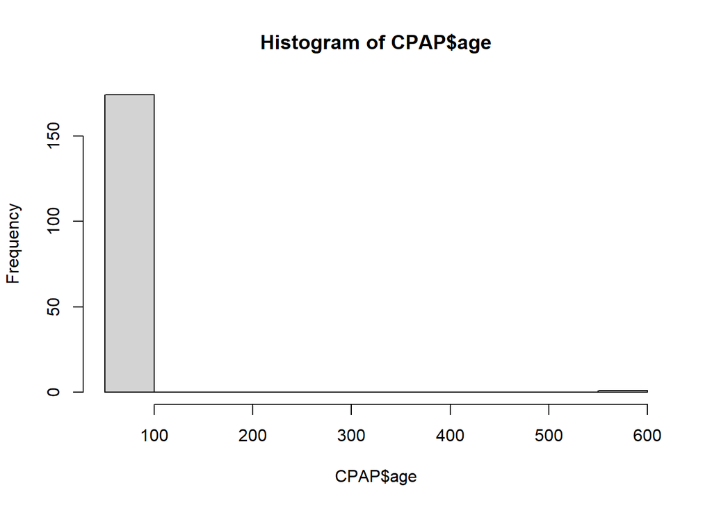

```r
hist(x=CPAP$age)
```

```r
weirdAges<-which(CPAP$age>=100)
print(x=weirdAges)
```

```
## [1] 5
```

```r
CPAP$age[weirdAges]
```

```
## [1] 555
```

```r
removeAges<-which(CPAP$age>= 100)
print(x=removeAges)
```

```
## [1] 5
```

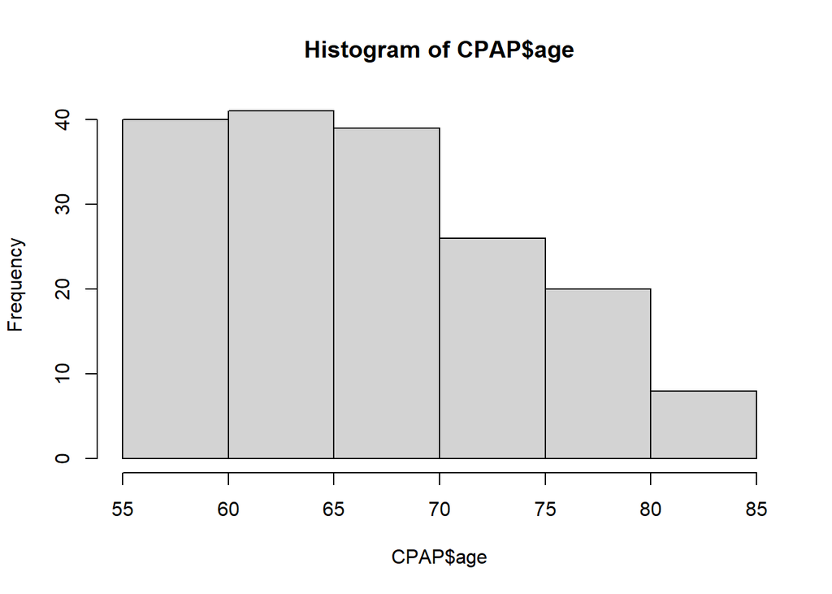

```r
CPAP<-CPAP[-removeAges, ]
hist(x=CPAP$age)
```

#Weird Age in Dataset #object 5 has error in age (555)****

#mmse #maximum possible is 30

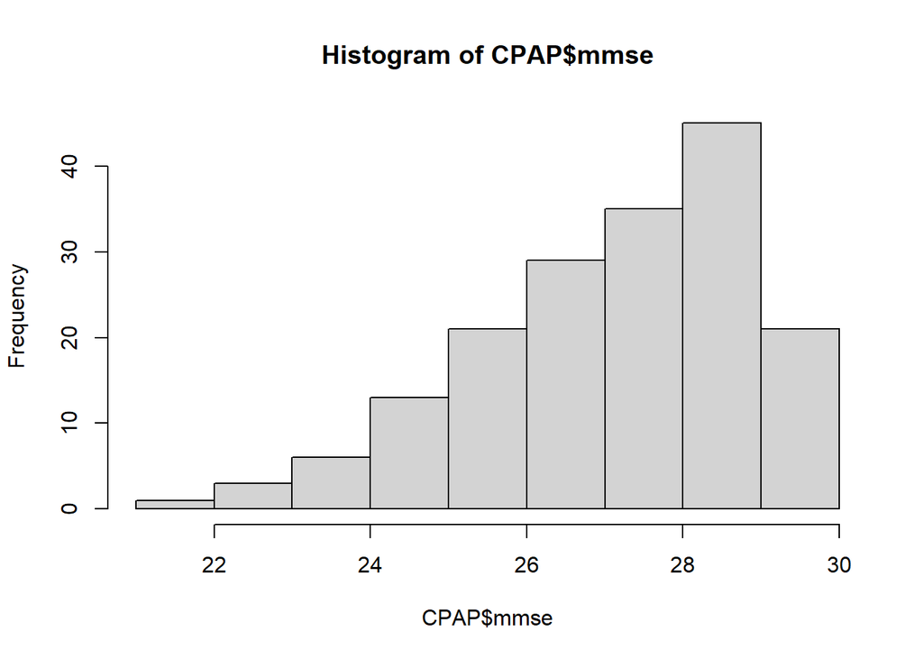

```r
hist(x=CPAP$mmse)
```

#ess #maximum possible is 24

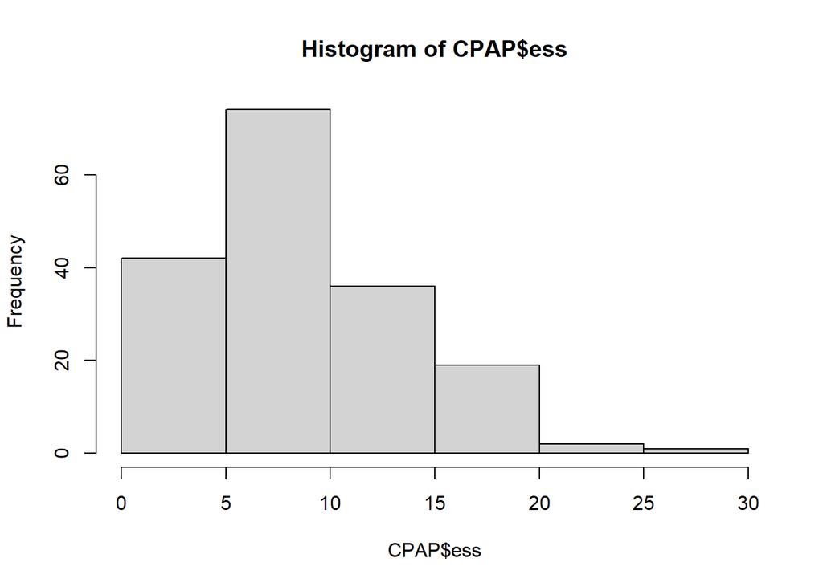

```r
hist(CPAP$ess)
```

```r
table(CPAP$ess)
```

```
##
##  0  1  2  3  4  5  6  7  8  9 10 11 12 13 14 15 16 17 18 19 20 22 30
##  3  5  7  7 10 10 25 10 16 14  9 11  3  8  6  8  3  8  4  2  2  2  1
```

#one obj has ess=30 which is impossible****

#AHI under 5 is impossible

```r
table (CPAP$ahi)
```

```
##
##    15  15.1  15.2  15.3  15.5  15.6  15.7  15.8  15.9    16  16.1  16.2  16.3
##     5     2     1     1     1     4     1     1     2     1     2     2     1
## 16.59  16.6  16.9  17.2  17.3  17.5  17.7  17.8    18  18.3  18.6    19  19.1
##     1     2     1     1     2     1     1     1     2     1     1     1     1
##  19.2  19.5  19.8  19.9    20  20.1  20.5  20.7  20.8  20.9    21  21.1  21.2
##     2     2     1     1     1     1     1     1     1     2     1     1     2
##  21.3  21.5  21.9    22  22.4  22.6  22.8  23.1  23.3  23.6  23.8    24  24.2
##     1     1     2     1     1     1     2     1     1     2     1     1     1
##  24.4  24.6  24.8  24.9  26.5  26.6  26.9  27.9    28  28.1  28.3  28.6  28.7
##     3     1     1     1     1     2     1     1     1     1     1     1     1
##  28.9  29.2  29.6    31  31.1  31.3  31.6    32  32.8  32.9    33  33.4  33.6
##     2     1     2     1     1     1     1     1     1     1     1     1     1
##  33.7  33.8  33.9    34  34.2  34.5  34.9  35.1  35.9  36.9    37  37.6  37.7
##     1     1     1     2     1     2     1     1     2     1     1     2     1
##  38.9    39  39.2  42.3    43  43.4  44.4  44.7  45.3  45.4  45.8  46.8 47.36
##     1     2     1     1     2     1     1     1     1     1     1     3     1
##    48  48.1  48.3  50.2  51.3  51.4  51.8  52.2  53.8  53.9  54.6  55.9  57.6
##     1     1     1     1     1     1     1     1     1     1     1     1     1
##  58.6  59.5    60  60.9    61  61.6    63  65.2  65.7    67  67.4    71  72.9
##     1     1     1     1     1     1     1     1     1     1     1     1     1
##  79.4  79.7    80  82.9  94.8  96.3  96.6 100.4 112.7 119.4
##     1     1     1     1     1     1     1     1     1     1
```

#race

```r
table(CPAP$race_white)
```

```
##
##   0   1   q
##  49 124   1
```

```r
table(CPAP$race_other)
```

```
##
##   0   1   p
## 161  12   1
```

```r
CPAP$race_other<-as.numeric(CPAP$race_other)
table(CPAP$race_other)
```

```
##
##   0   1
## 161  12
```

```r
CPAP$race_white<-as.numeric(CPAP$race_white)
table(CPAP$race_white)
```

```
##
##   0   1
##  49 124
```

#0NE missing Data in RACE_WHITE **** #ONE MISSING DATA IN RACE_OTHER**** #education

```r
table(CPAP$education)
```

```
##
##                <= high school  > high school
##              1             36            137
```

#ONE MISSING DATA IN EDUCATION**** #sex

```r
table(CPAP$sex)
```

```
##
##  0  1  2
## 95 78  1
```

#ONE MISCONSISTENCY: IN SEX:2 IS NOT DEFINE **** #ID

```r
duplicated(x=CPAP$subject_id)
```

```
##   [1] FALSE FALSE FALSE FALSE FALSE FALSE FALSE FALSE FALSE FALSE FALSE FALSE
##  [13] FALSE FALSE FALSE FALSE FALSE FALSE FALSE FALSE FALSE FALSE FALSE FALSE
##  [25] FALSE FALSE FALSE FALSE FALSE FALSE FALSE FALSE FALSE FALSE FALSE FALSE
##  [37] FALSE FALSE FALSE FALSE FALSE FALSE FALSE FALSE FALSE FALSE FALSE FALSE
##  [49] FALSE FALSE FALSE FALSE FALSE FALSE FALSE FALSE FALSE FALSE FALSE FALSE
##  [61] FALSE FALSE FALSE FALSE FALSE FALSE FALSE FALSE FALSE FALSE FALSE FALSE
##  [73] FALSE FALSE FALSE FALSE FALSE FALSE FALSE FALSE FALSE FALSE FALSE FALSE
##  [85] FALSE FALSE FALSE FALSE FALSE FALSE FALSE FALSE FALSE FALSE FALSE FALSE
##  [97] FALSE FALSE FALSE FALSE FALSE FALSE FALSE FALSE FALSE FALSE FALSE FALSE
## [109] FALSE FALSE FALSE FALSE FALSE FALSE FALSE FALSE FALSE FALSE FALSE FALSE
## [121] FALSE FALSE FALSE  TRUE FALSE FALSE FALSE FALSE FALSE FALSE FALSE FALSE
## [133] FALSE FALSE FALSE FALSE FALSE FALSE FALSE FALSE FALSE FALSE FALSE FALSE
## [145] FALSE FALSE FALSE FALSE FALSE FALSE FALSE FALSE FALSE FALSE FALSE FALSE
## [157] FALSE FALSE FALSE FALSE FALSE FALSE FALSE FALSE FALSE FALSE FALSE FALSE
## [169] FALSE FALSE FALSE FALSE FALSE FALSE
```

```r
which(x=duplicated(x=CPAP$subject_id))
```

```
## [1] 124
```

```r
dupSpot<-which(x=duplicated(x=CPAP$subject_id))
CPAP<-CPAP[-dupSpot, ]
```

#row 125 is duplicated *******

# Create a single race variable

```r
CPAP$race_white<-ifelse(CPAP$race_white==1,"yes","NO")
table(CPAP$race_white)
```

```
##
##  NO yes
##  49 123
```

```r
CPAP$race <- ifelse(CPAP$race_black == 1, "Black",
             ifelse(CPAP$race_white == "yes", "White",
            ifelse(CPAP$race_other == 1, "Other", NA)))
```

#creat a binary Adherence varriable

```r
CPAP$adherence <- ifelse(CPAP$avg_daily_cpap >= 4, "Adherent",
                  ifelse(CPAP$avg_daily_cpap < 4, "Non-Adherent", NA))
```

#visualization

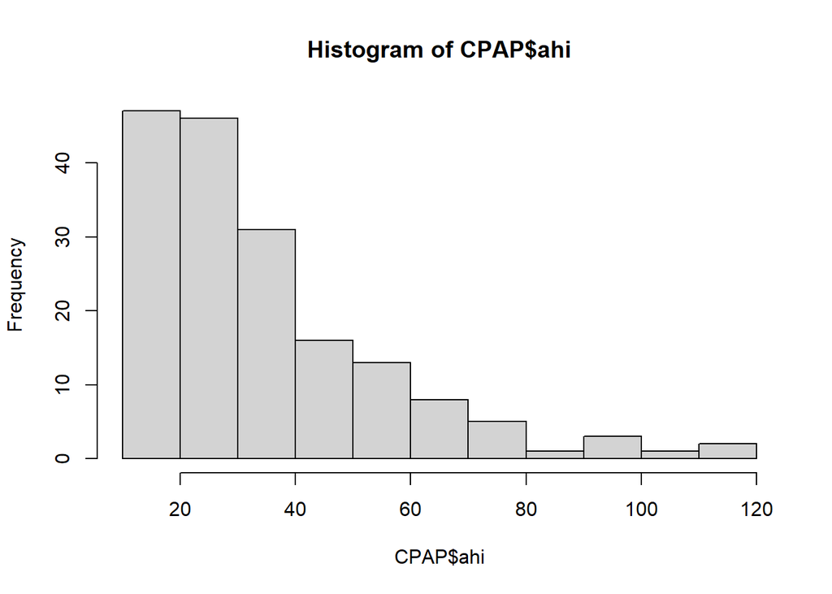

```r
hist(CPAP$ahi)
```

**** #THE HISTOGRAM SHOWES RIGHT SKEWED DISTRIBUTION IN AHI;meaning most individuals have lower AHI values while fewer have very high values. extreme cases of high AHI are less common but still present. the average is higher by these extreme values compared to the median.****

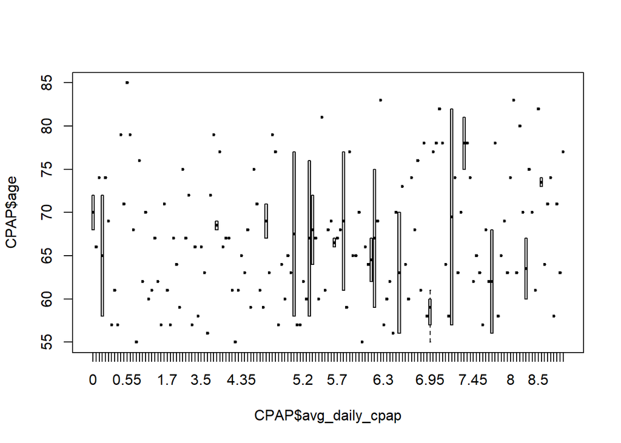

```r
boxplot(CPAP$age~CPAP$avg_daily_cpap)
```

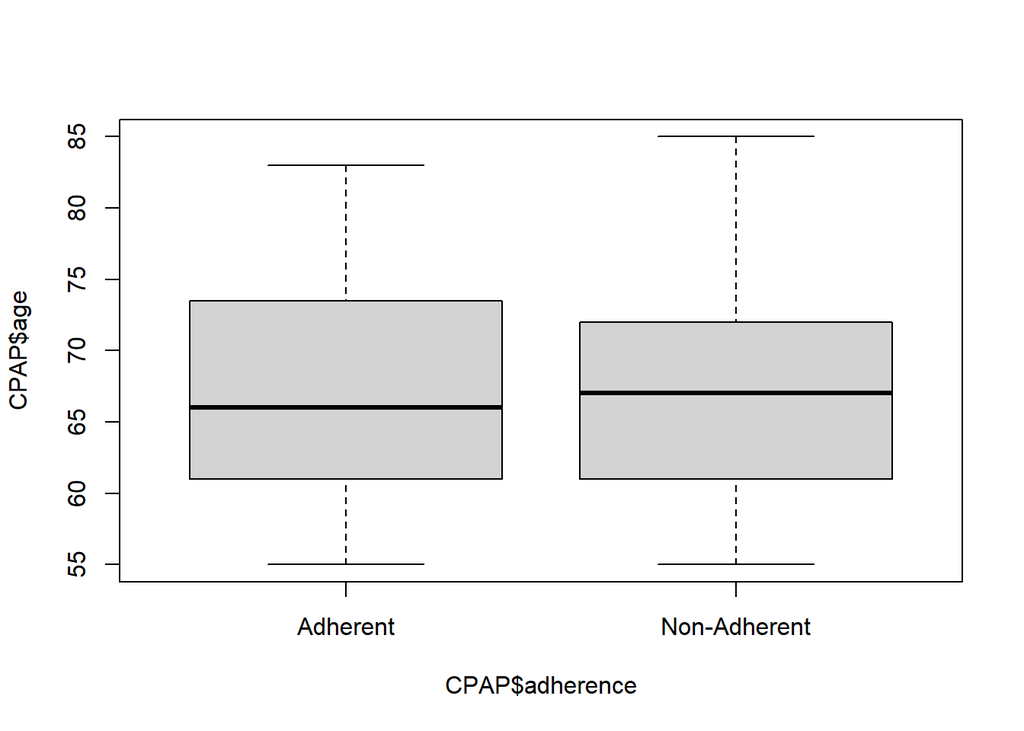

```r
boxplot(CPAP$age~CPAP$adherence)
```

#*The boxplot shows that age distributions differ slightly across adherence categories. Both groups have similar medians, but the adherent group displays a wider interquartile range and greater variability in age.this is a bivariate display because it compares age across adherence categories.***

# Create barplot to compare race distributions across adherence groups

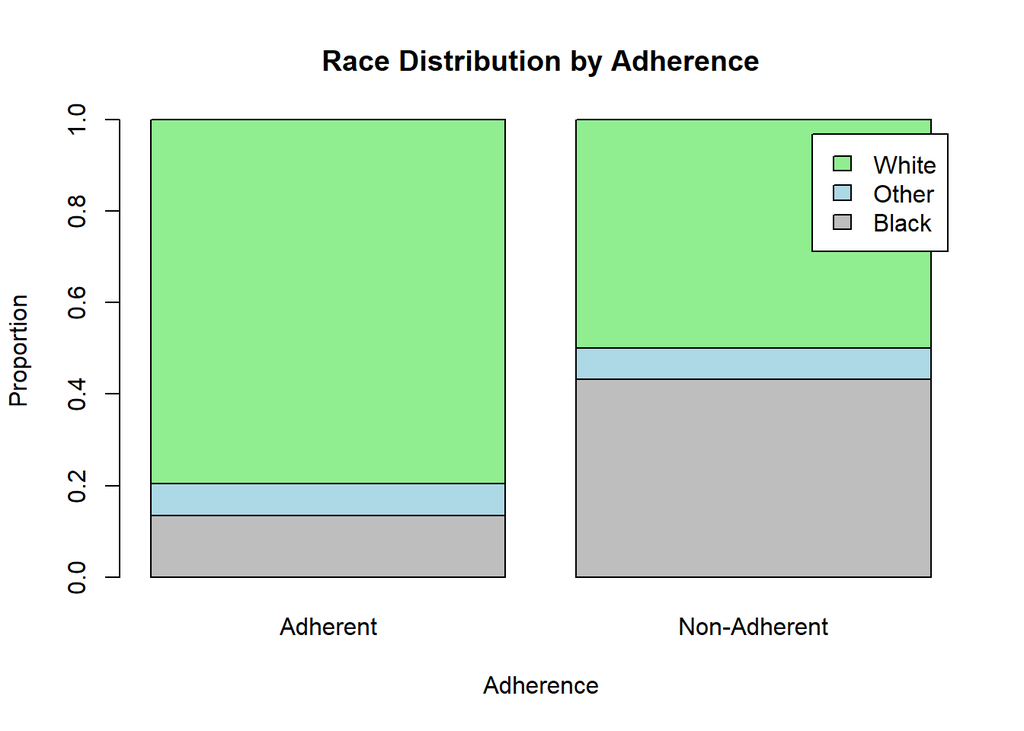

```r
tab <- table(CPAP$adherence, CPAP$race)
prop_tab <- prop.table(tab, margin = 1)
barplot(t(prop_tab),
        beside = FALSE,
        col = c("grey", "lightblue", "lightgreen", "pink"),
        legend = colnames(prop_tab),
        main = "Race Distribution by Adherence",
        xlab = "Adherence", ylab = "Proportion")
```

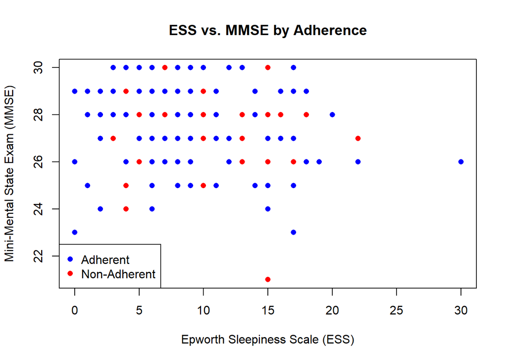

```r
plot(CPAP$ess, CPAP$mmse,
     col = ifelse(CPAP$adherence == "Adherent", "blue", "red"),
     pch = 16,
     main = "ESS vs. MMSE by Adherence",
     xlab = "Epworth Sleepiness Scale (ESS)",
     ylab = "Mini-Mental State Exam (MMSE)")
legend("bottomleft", legend = c("Adherent", "Non-Adherent"),
       col = c("blue", "red"), pch = 16)
```

#The scatterplot shows no strong linear relationship between ESS and MMSE. A slight negative trend is visible, suggesting higher sleepiness might correspond to slightly lower cognitive scores. Both adherence groups follow similar patterns without clear differences. This is a bivariate display.****

#Table 1 and its description.

```r
summary(CPAP[, c("age", "ahi", "ess", "mmse", "avg_daily_cpap")])
```

```
##       age             ahi              ess              mmse
##  Min.   :55.00   Min.   : 15.00   Min.   : 0.000   Min.   :21.00
##  1st Qu.:61.00   1st Qu.: 19.50   1st Qu.: 6.000   1st Qu.:26.00
##  Median :67.00   Median : 28.60   Median : 8.000   Median :28.00
##  Mean   :66.92   Mean   : 34.88   Mean   : 9.012   Mean   :27.59
##  3rd Qu.:72.00   3rd Qu.: 44.70   3rd Qu.:13.000   3rd Qu.:29.00
##  Max.   :85.00   Max.   :119.40   Max.   :30.000   Max.   :30.00
##  avg_daily_cpap
##  Min.   : 0.000
##  1st Qu.: 3.800
##  Median : 5.667
##  Mean   : 5.254
##  3rd Qu.: 7.083
##  Max.   :21.167
```

# Stratified summaries

```r
by(CPAP[, c("age", "ahi", "ess", "mmse", "avg_daily_cpap")], CPAP$adherence, summary)
```

```
## CPAP$adherence: Adherent
##       age             ahi              ess              mmse
##  Min.   :55.00   Min.   : 15.00   Min.   : 0.000   Min.   :23.00
##  1st Qu.:61.00   1st Qu.: 19.50   1st Qu.: 6.000   1st Qu.:26.00
##  Median :66.00   Median : 26.75   Median : 8.000   Median :28.00
##  Mean   :66.98   Mean   : 34.47   Mean   : 8.969   Mean   :27.65
##  3rd Qu.:73.25   3rd Qu.: 43.65   3rd Qu.:12.250   3rd Qu.:29.00
##  Max.   :83.00   Max.   :112.70   Max.   :30.000   Max.   :30.00
##  avg_daily_cpap
##  Min.   : 4.017
##  1st Qu.: 5.312
##  Median : 6.508
##  Mean   : 6.539
##  3rd Qu.: 7.487
##  Max.   :21.167
## ------------------------------------------------------------
## CPAP$adherence: Non-Adherent
##       age             ahi              ess              mmse
##  Min.   :55.00   Min.   : 15.10   Min.   : 1.000   Min.   :21.00
##  1st Qu.:61.00   1st Qu.: 20.50   1st Qu.: 6.000   1st Qu.:27.00
##  Median :67.00   Median : 33.80   Median : 9.000   Median :28.00
##  Mean   :66.76   Mean   : 36.03   Mean   : 9.133   Mean   :27.42
##  3rd Qu.:72.00   3rd Qu.: 47.36   3rd Qu.:13.000   3rd Qu.:29.00
##  Max.   :85.00   Max.   :119.40   Max.   :22.000   Max.   :30.00
##  avg_daily_cpap
##  Min.   :0.0000
##  1st Qu.:0.3167
##  Median :1.2667
##  Mean   :1.6004
##  3rd Qu.:2.8833
##  Max.   :3.9833
```

# Categorical variables

```r
table(CPAP$adherence, CPAP$sex)
```

```
##
##                 0  1  2
##   Adherent     70 57  1
##   Non-Adherent 24 21  0
```

```r
table(CPAP$adherence, CPAP$race)
```

```
##
##                Black Other White
##   Adherent        17     9   101
##   Non-Adherent    19     3    22
```

```r
table(CPAP$adherence, CPAP$ethnicity)
```

```
##
##                Hispanic or Latino Not Hispanic or Latino
##   Adherent                     10                    118
##   Non-Adherent                  3                     42
```

```r
table(CPAP$adherence, CPAP$education)
```

```
##
##                    <= high school > high school
##   Adherent       1             24           103
##   Non-Adherent   0             12            33
```

# Load package

```r
library(tableone)
tab1 <- CreateTableOne(data = CPAP[, c(3,7,8,9,10,12,13)])
```

# Print the table

```r
print(tab1)
```

```
##
##                              Overall
##   n                            173
##   education (%)
##                                  1 ( 0.6)
##      <= high school             36 (20.8)
##      > high school             136 (78.6)
##   age (mean (SD))            66.92 (7.48)
##   sex (mean (SD))             0.46 (0.51)
##   ahi (mean (SD))            34.88 (20.84)
##   ess (mean (SD))             9.01 (5.23)
##   avg_daily_cpap (mean (SD))  5.25 (2.78)
##   race (%)
##      Black                      36 (21.1)
##      Other                      12 ( 7.0)
##      White                     123 (71.9)
```

[output not shown]